# Technologie wytwarzania elementów urządzeń mechatronicznych

dr hab. inż. Marcin Słoma, prof. PW

Zakład Mikrotechnologii i Nanotechnologii

## TECHNOLOGIA POWŁOK

Powłoka to warstwa materiału wytworzona lub nałożona na powierzchnię elementu w sposób naturalny lub sztuczny. Powłoka jest wykonana z innego materiału niż element. Celem powłoki jest uzyskanie określonych właściwości ochronnych, technicznych lub dekoracyjnych.

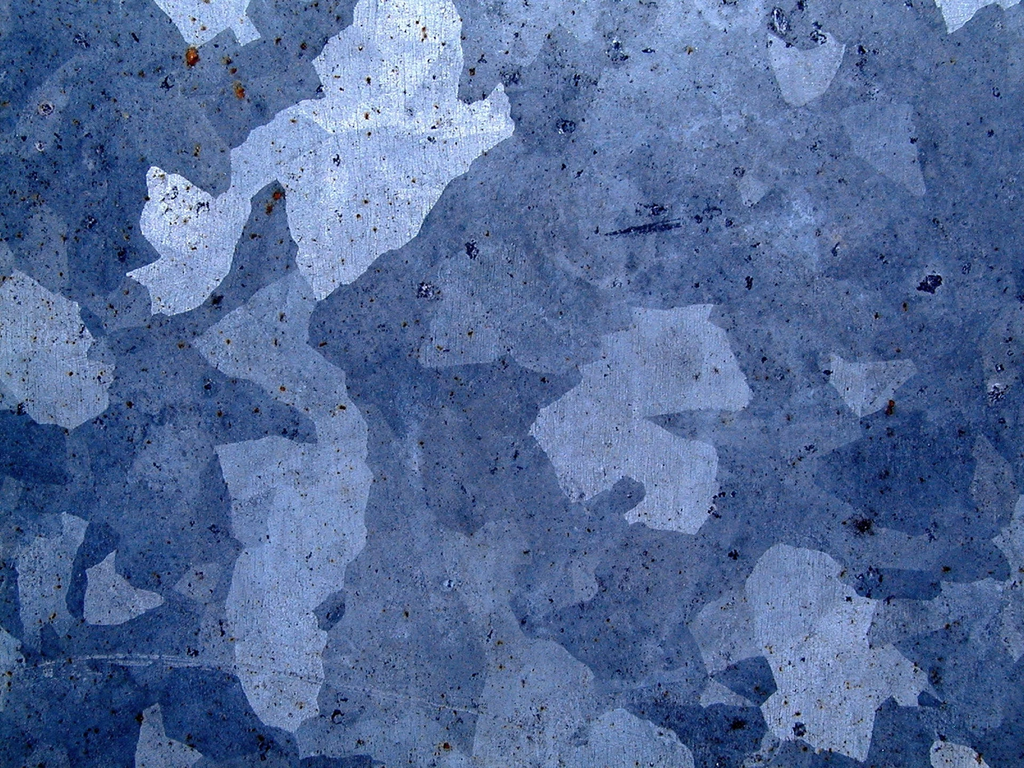

[figure not shown]

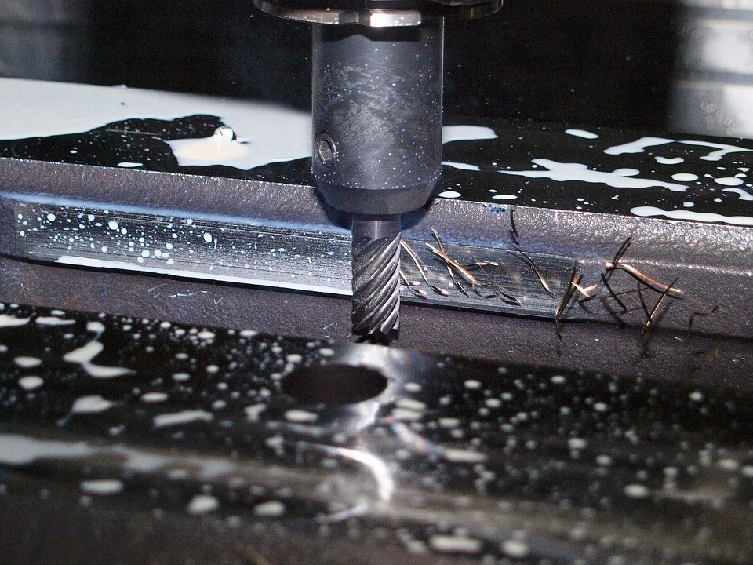

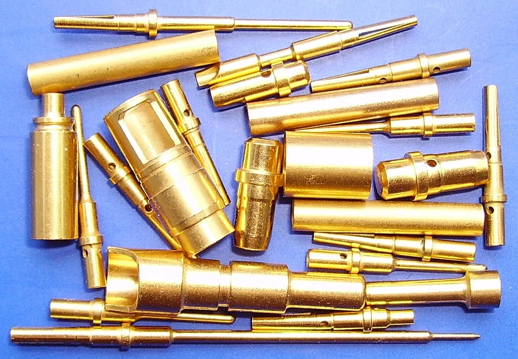

[figure not shown]

[figure not shown]

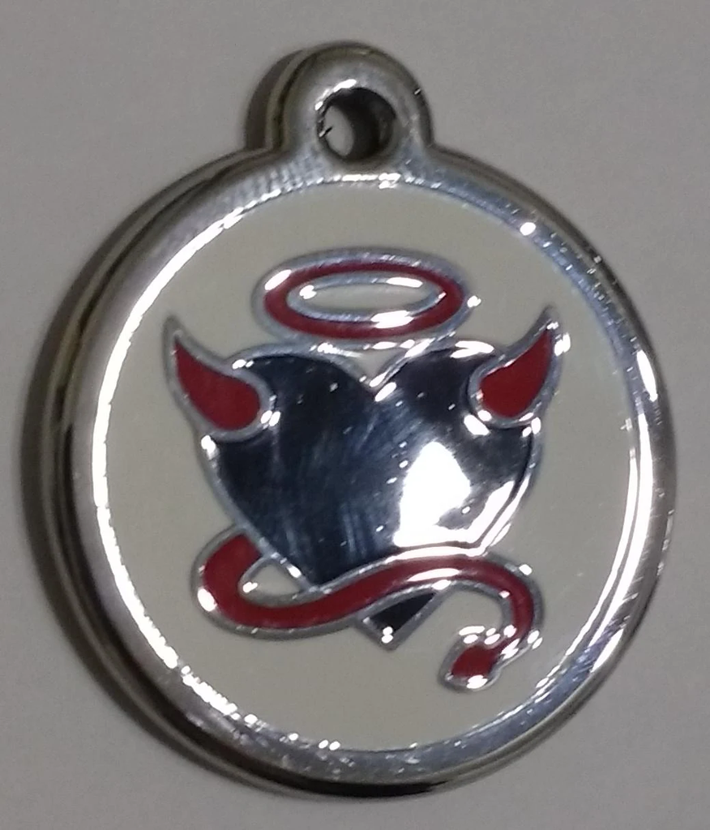

## POWŁOKI ORGANICZNE

### POWŁOKI MALARSKO-LAKIERNICZE

Są to powłoki z tworzyw sztucznych, nanoszone w stanie ciekłym lub stałym, utwardzane chemicznie, przez odparowanie rozpuszczalników lub termicznie przez przetopienie cząstek.

- farby
- lakiery
- (emalie)

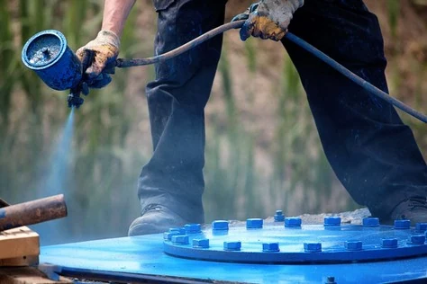

[figure not shown]

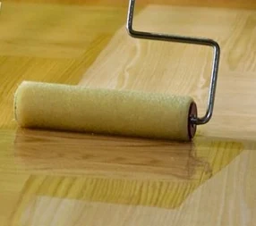

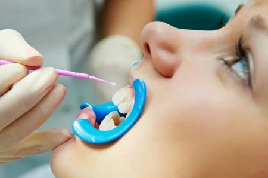

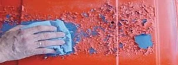

Pneumat System, B&P Service, Vidaron, Autobilid.de, Anardi

## POWŁOKI ORGANICZNE

### POWŁOKI MALARSKO-LAKIERNICZE

### SKŁAD

- Substancje organiczne (spoiwa, substancje błonotwórcze)
- Olejne pokostowe
- Olejno‐żywiczne
- Ftalowe modyfikowane olejami (alkidowe)
- Ftalowo‐aminowe
- Kreodurowe
- Poliwinylowe, chlorokauczukowe
- Epoksydowe
- Nitrocelulozowe
- Akrylowe i metakrylowe
- Ftalowe styrenowane
- Emulsyjne: Poli(octan winylu), kopolimery styrenowo‐akrylowe
- …

## POWŁOKI ORGANICZNE

### POWŁOKI MALARSKO-LAKIERNICZE - SKŁAD

### Rozpuszczalniki i rozcieńczalniki

- Produkty ciekłe o możliwie niskiej temperaturze wrzenia i małej wartości ciepła parowania.
- Nie wchodzą one w skład powłok - regulują sposób nanoszenia powłoki i jej jakość.
- Przykłady: aceton, alkohole (izopropylowy, etylowy), benzyna, cyklododekan, …

Coraz częściej rozpuszczalniki organiczne są eliminowane, na rzecz wody i alkoholi (farby emulsyjne lub wodorozcieńczalne) i farb bezrozpuszczalnikowych (farby proszkowe, fotoutwardzalne).

[figure not shown]

## POWŁOKI ORGANICZNE

### POWŁOKI MALARSKO-LAKIERNICZE - SKŁAD

### Pigment i napełniacze

- dekoracyjne
- nadanie odporności na działanie światła
- ograniczenie pęcznienia w wodzie (wobec pary wodnej) i w rozpuszczalnikach,
- pasywacja powierzchni metalu,
- ochrona elektrochemiczna (pył cynkowy),
- zobojętnianie czynników kwaśnych (pigmenty zasadowe),
- zwiększenie twardości i odporności na zarysowanie,
- właściwości specjalne (przewodnictwo elektryczne i cieplne, luminescencja, właściwości dielektryczne i magnetyczne, …)
- …

## POWŁOKI ORGANICZNE

### POWŁOKI MALARSKO-LAKIERNICZE - SKŁAD

### Składniki modyfikujące i uszlachetniające

- zapobiegające korzuszeniu,
- zwilżające,
- zagęszczające i tiksotropujące,
- poprawiające rozlewność (zapobiegają powstawaniu pęcherzyków powietrza),
- peptyzujące (zapobiegają ścinaniu),
- matujące (zmniejszają połysk),
- przeciwdziałające powstawaniu piany,
- bakterio‐, grzybo‐ i owadobójcze,
- inne (nadające odporność na działanie UV, inhibitujące korozję itp.).

## POWŁOKI ORGANICZNE

### POWŁOKI MALARSKO-LAKIERNICZE - NANOSZENIE

### Produkcyjne sposoby nanoszenia powłok malarsko-lakierniczych

- zanurzeniowe,
- walcami (blachy, taśmy),
- natryskowe (pneumatyczne, hydrodynamiczne),
- w bębnach (elementy drobne),
- pędzlami, wałkami,
- elektroforetyczne.
- Po nałożeniu warstwy konieczne jest jej wysuszenie.
- Lakiery piecowe wymagają wypalania (utleniania) w celu utwardzenia.
- Temperatury suszenia/wypalania (20°C) 60÷160°C.

[figure not shown]

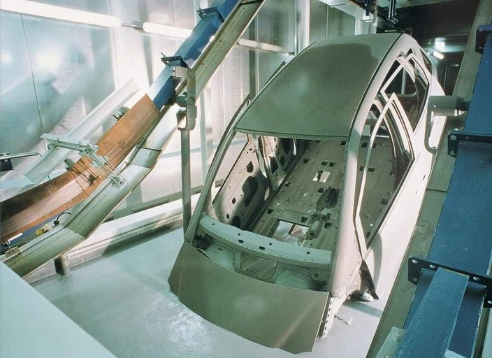

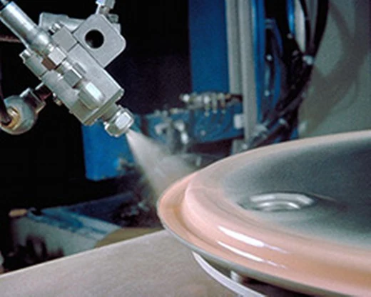

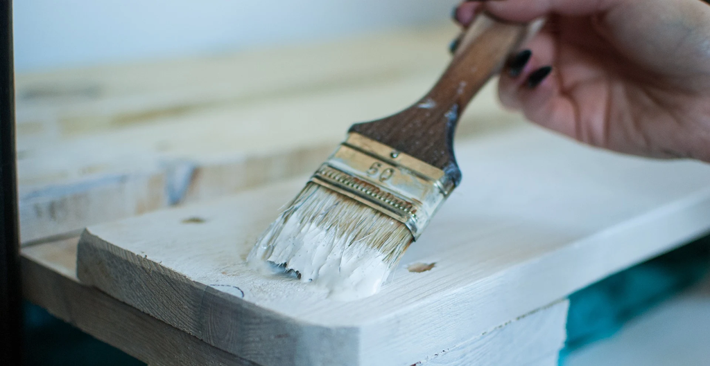

BASF, Esiproof, Nordson, Alcor

## POWŁOKI ORGANICZNE

### POWŁOKI MALARSKO-LAKIERNICZE - NANOSZENIE

### Metody natryskowe

- pneumatyczna
- hydrodynamiczna

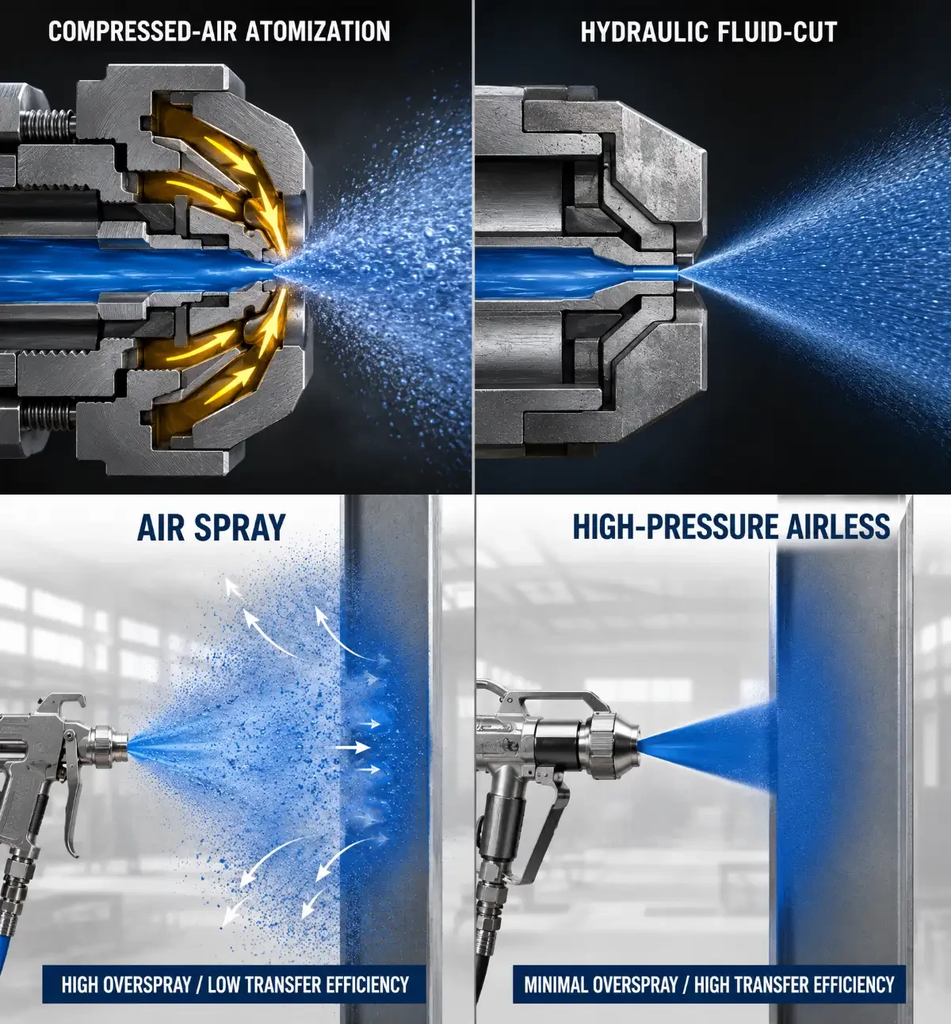

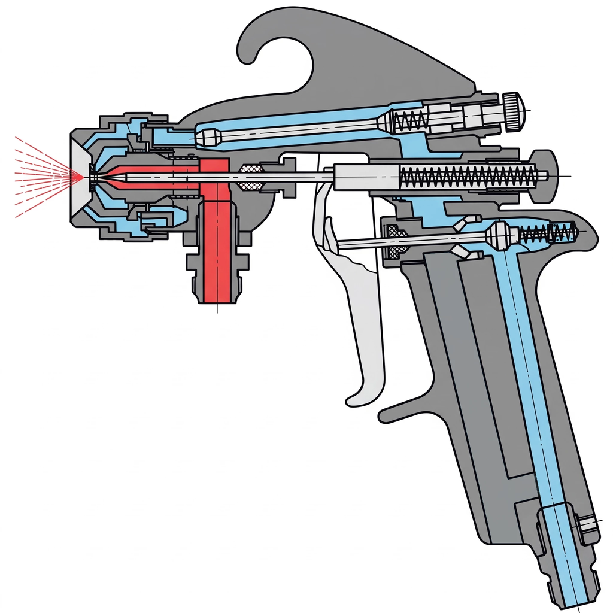

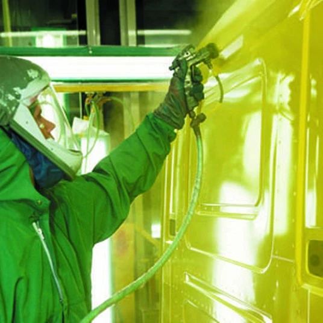

AFS, Aquamist, Gutubao

## POWŁOKI ORGANICZNE

### POWŁOKI MALARSKO-LAKIERNICZE - NANOSZENIE - Metody natryskowe

[interactive chart not shown]

Pneumatico.pl, https://www.youtube.com/watch?v=Vjw3KRXOZW0

## POWŁOKI ORGANICZNE

### POWŁOKI MALARSKO-LAKIERNICZE - NANOSZENIE - Metody zanurzeniowe

[interactive chart not shown]

Jim Paterson https://www.youtube.com/watch?v=JauUjmXlTPE

## POWŁOKI ORGANICZNE

### POWŁOKI PROSZKOWE

### Powlekanie elektrostatyczne i fluidyzacyjne

Farby proszkowe: substancje termoplastyczne i termoutwardzalne (żywice epoksydowe, żywice poliestrowe, poliuretany i silikony, mieszanki poliestrowo‐epoksydowe).  
Elementy są powlekane mgłą (aerozolem) proszku w stanie stałym. Proszek o wymiarach ziaren w przedziale µm może być nanoszony technikami:

- fluidyzacji,
- elektrostatyczną.

Po pomalowaniu elementy są nagrzewane (150÷250°C), w rezultacie czego farba proszkowa ulega przetopieniu tworząc jednolitą powłokę polimerową.

## POWŁOKI ORGANICZNE

### POWŁOKI PROSZKOWE

### Powlekanie fluidyzacyjne

Fluidyzacja jest procesem, w którym farba w proszku nabiera cech materiałów płynnych (aerozolu) w wyniku przedmuchiwania farby od dołu ku górze za pomocą gazów.

[figure not shown]

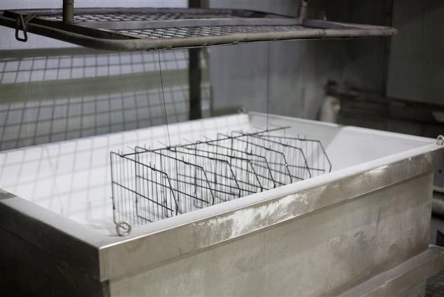

*Przykład aerozolu proszkowego?*

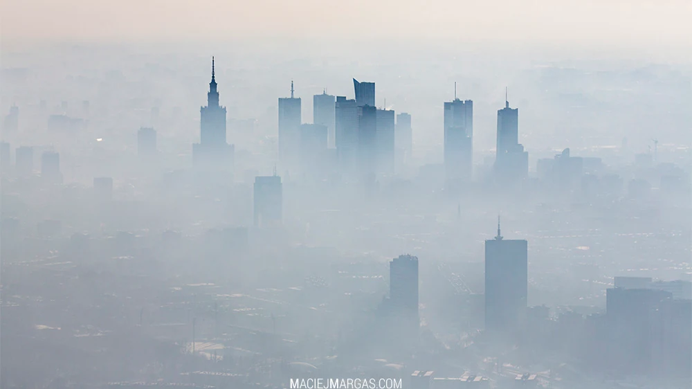

Bater, Poldrut

## POWŁOKI ORGANICZNE

### POWŁOKI PROSZKOWE - NANOSZENIE - Powlekanie fluidyzacyjne

[interactive chart not shown]

BOSTEK - KIGO Scandinavia, Baltic & Poland https://www.youtube.com/watch?v=2C1z0PobLao

## POWŁOKI ORGANICZNE

### POWŁOKI PROSZKOWE

### Powlekanie elektrostatyczne

Powlekanie elektrostatyczne jest podobne do natrysku pneumatycznego, z tą różnicą że materiał powłoki występuje w postaci proszku (a nie ciekłej). Ziarna proszku uzyskują ładunek elektryczny w dyszy pistoletu, a następnie jest przyspieszany pneumatycznie i osiadają na uziemionych elementach.

[figure not shown]

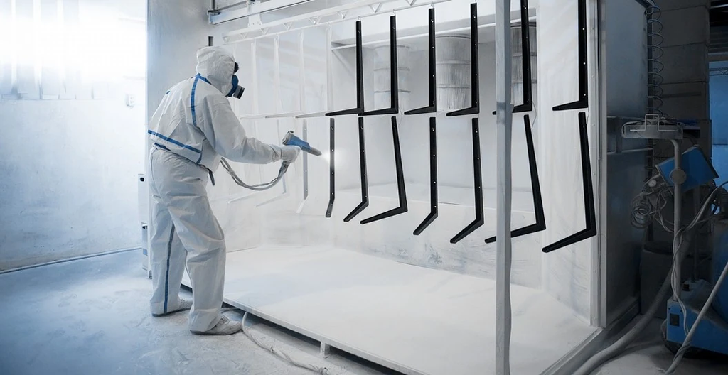

Wagner, Rutmal

## POWŁOKI ORGANICZNE

### POWŁOKI PROSZKOWE - NANOSZENIE - Powlekanie elektrostatyczne

[interactive chart not shown]

AutoshineWheelClinic https://www.youtube.com/watch?v=HJpPM0Zn_hc

## POWŁOKI NIEORGANICZNE

### EMALIE SZKLISTE

Masy emalierskie składające się z tlenków, fluorków, boranów i krzemianów metali. Są to substancje wyłącznie nieorganiczne i należy je odróżniać od lakierów nazywanych potocznie emaliami.

NAKŁADANIE WARSTWY ⇒ SUSZENIE ⇒ WYPALANIE (przetopienie, spiekanie) 500÷1000°C

- Zastosowania ogólne i techniczne:
- Pokrycia naczyń kuchennych i stołowych, zarówno metalowych jak i ceramicznych.
- Ceramika łazienkowa: wanny, umywalki, glazura (kafelki).
- Pokrycia izolatorów ceramicznych i grzejników oporowych.
- Szkliwa do wykonywania układów grubowarstwowych.
- Mozaiki, wyroby jubilerskie: ozdoby, medalierstwo, pamiątki.

## POWŁOKI NIEORGANICZNE

### EMALIE SZKLISTE

[figure not shown]

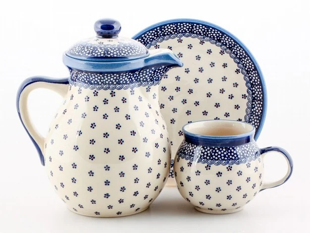

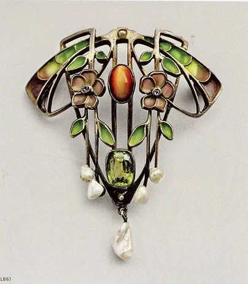

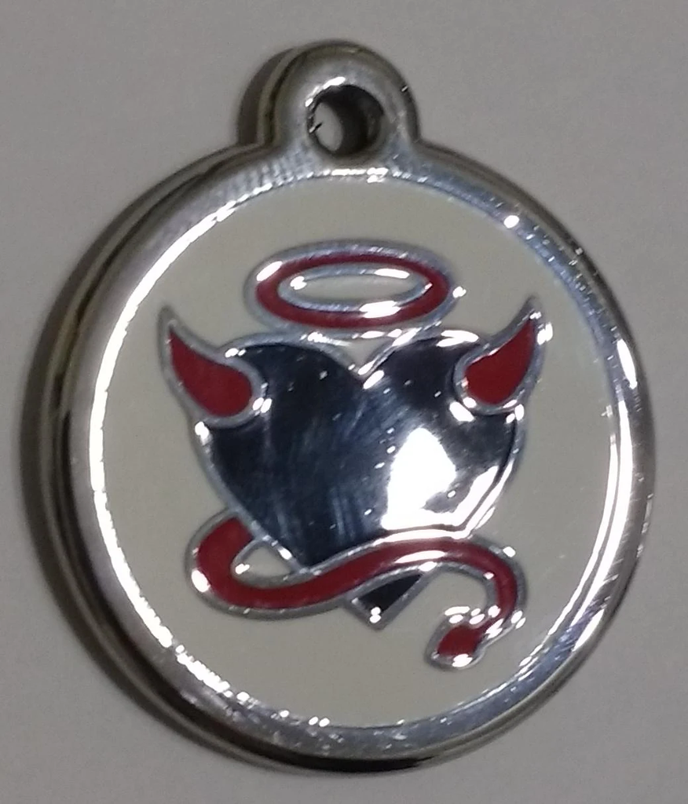

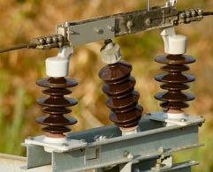

[figure not shown]

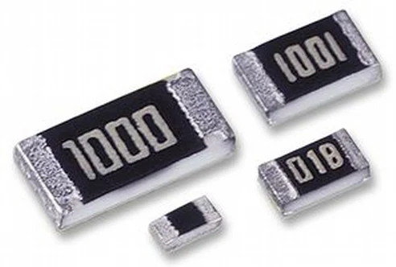

Elektroonline, KristoArts, Emalia Olkusz, Bolesławiec, Heraeus, Farnell